# How to generate a binned line plot from flow cytometry data using R

## The problem with the dot plot

Data produced from a dual-color flow cytometry experiment typically look like the scatter plots below, where one dot represents one cell, and x- and y-axes represent features of interest within each cell.

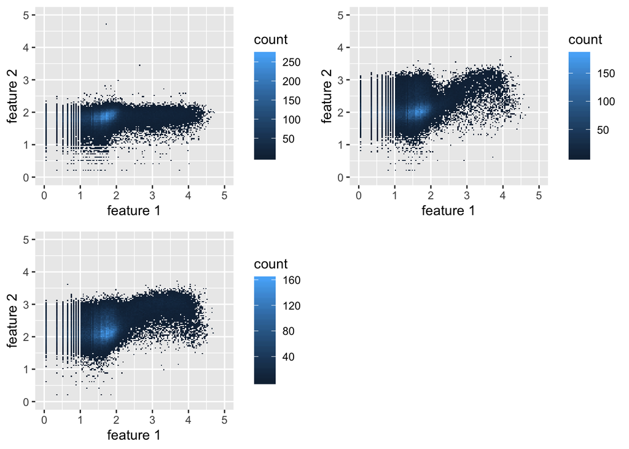

While this can be a helpful way to understand the relationship between the two features within a cell, it’s difficult to interpret small changes between samples with side-by-side scatter plots.

To facilitate comparison of multiple samples by plotting them on a single graph, I composed the code below to import, clean, and plot data accordingly.

## But first, libraries

ggplot2 and dplyr libraries are from the ‘Tidyverse’ package in R and will be necessary later when we plot the data.

```r
library(ggplot2) # generates different types of plots
library(dplyr) # facilitates manipulation of dataframes
```

## Importing the data

Here, I assume that the data are already in CSV format. (If not, you might have to open your FCS file in FlowJo or FACSDiva software and export it to a CSV for this step!)

```r
# assign the data within your csv to an intuitive variable name
control = read.csv('control.csv') # negative control data that should not show signal in the y axis
protein1 = read.csv('experimentalSample1.csv') # experimental sample 1
protein2 = read.csv('experimentalSample2.csv') # experimental sample 2
```

## Parameters typically recorded in each flow experiment

Those familiar with flow cytometry will recognize the column headings below.

```r
# view a sample dataset
head(protein2)
```

```
##      FSC.A    FSC.W    SSC.A  SSC.W   APC.A  FITC.A     Time
## 1 128578.0  97711.8  71490.7 101513   95.20    4.48 0.553077
## 2 121995.0 120892.0 121140.0 142374 1106.70 2106.72 0.554099
## 3  75197.8 117483.0  66933.4 107535   65.45   39.20 0.555122
## 4  59231.9  98789.2  79898.6 125455  162.35   80.64 0.555122
## 5 131126.0  96366.5  66477.6 101784   68.85   36.96 0.556144
## 6  59576.0  90008.1  80544.8 125043  102.00   69.44 0.557166
```

For the uninitiated, the labels translate to the following cellular features:

- **FSC** = forward scatter, which tells us about each cell’s size
- **SSC** = side scatter, which tells us about each cell’s granularity
- **APC** = some feature of interest that the experimenter has chosen to make detectable using a fluorescent marker, which emits signal at ~660 nm
- **FITC** = same as APC, except its emission wavelength is around ~520 nm
- **Time** = The time (in seconds) each cell passed through the laser, generating the data above
- **.A** refers to the area under the fluorescent curve generated from each event (i.e. each cell) and tells us how intense the signal for each parameters was
- **.W** refers to the width of the fluorescent curve generate from each event and plays a role in what’s called a “gating” process, which isn’t covered here

## Subsetting the data of interest

My experimental question was: Relative to the control protein (“control”), does protein 1 (“protein1”) or protein 2 (“protein2”) induce more proliferative signal within each cell?

As alluded to above, I’m particularly interested in the APC and FITC columns. In my case, FITC measurements tell me how abundant a protein of interest is in each cell. A more intense FITC reading therefore means that cell contains a higher number of that specific protein.

The APC-labelled feature provides information about each cell’s intracellular signaling activity. An intense reading here means that the cell is receiving a lot of signal to divide and proliferate (think cancer).

Now that the data are imported, I want to extract the columns containing experimental information:

```r
# generates a new variable containing a dataframe of only FITC and APC columns
controlDat = subset(control, select = c('FITC.A', 'APC.A'))
protein1Dat = subset(protein1, select = c('FITC.A', 'APC.A'))
protein2Dat = subset(protein2, select = c('FITC.A', 'APC.A'))
```

## Clean it up

After subsetting the features of interest into a new dataframe, I want to view summary statistics of each parameter in my experiment to get an idea of the quality of the data.

```r
# compute summary statistics of each column within the specified sample dataframe
summary(protein2Dat)
```

```
##      FITC.A             APC.A
##  Min.   : -108.64   Min.   : -15.3
##  1st Qu.:   11.20   1st Qu.: 105.4
##  Median :   38.08   Median : 171.7
##  Mean   :  406.70   Mean   : 294.5
##  3rd Qu.:   73.92   3rd Qu.: 345.9
##  Max.   :48875.70   Max.   :5236.9
```

In evaluating these statistics, I can see that both FITC and APC data ‘min’ values are negative, implying the datasets contain negative, and possibly 0 values. Because flow data are generally reported on a log scale, I want to clean the data of these values to prevent generating an error when applying a log transform:

*Note: there are a number of ways to handle NA values, including imputation. However, removal is sufficient for my purposes.*

```r
# combine dataframes of the three samples into a list
datasets <- list(control = controlDat, protein1 = protein1Dat, protein2 = protein2Dat)

# generate a new variable where negative and 0 values within each dataframe in datasets have been removed
datasets.clean <- lapply(datasets, function(dataset) {
  dataset[dataset <= 0] <- NA
  dataset <- na.omit(dataset)
})
```

### Double check

I confirm that only non-negative data remain by again viewing summary statistics of the three samples:

```r
# compute example of summary statistics to confirm removal of negative/0 data
summary(datasets.clean[["protein2"]])
```

```
##      FITC.A             APC.A
##  Min.   :    1.12   Min.   :   0.85
##  1st Qu.:   25.76   1st Qu.: 107.95
##  Median :   48.16   Median : 177.65
##  Mean   :  491.78   Mean   : 310.04
##  3rd Qu.:   85.12   3rd Qu.: 367.20
##  Max.   :48875.70   Max.   :5236.85
```

## Transform the data

Minimum values of both FITC and APC data are now positive numbers!

In the next step, I will log transform each value, as that is the scale I want to use when visualizing the data; this is standard for flow cytometry data:

```r
# calculates log10 of each value in the current dataset
datasets.clean.log <- lapply(datasets.clean, function(dataset) {
  log10(dataset)
})
```

## A function to bin values along the x axis and calculate the mean of corresponding y axis values

Now that the data have been transformed, it’s time to bin the values and calculate the means of each bin.

Because I want to know how protein abundance (FITC data, x-axis) relate to intracellular activity (APC data, y-axis), I will bin the values according to FITC intensity and calculate the mean of the corresponding APC values using a custom function:

*Note: the current version of this function does not include error handling! To successfully implement the code below on your data, ensure the ‘dataset’ passed into the function is a dataframe where desired x-axis data are in column 1 and desired y-axis data are in column 2.*

```r
  binnedMeans <- function(dataset, binwidth) {

    # assign column 1 data to x; column 2 data to y
    x <- dataset %>% select(1)
    y <- dataset %>% select(2)

    # generate vector of values from 0 to maximum x
    bins <- seq(from = 0, to = max(x), by = binwidth);

    # initiate empty vectors into which values calculated within for loop below will be passed
    x_bin <- vector("numeric", 100);
    x_n <- vector("numeric", 100);
    y_means <- vector("numeric", 100);
    y_SEMs <- vector("numeric", 100);

    count <- 1

    for(bin in bins) {

      # locate and count x values within specified bin
      x_values <- x > bin & x <= (bin + binwidth);
      x_n[count] <- sum(x_values);

      # calculate and store mean of y values corresponding to 'x_values'
      y_mean <- mean(y[x_values]);
      y_means[count] <- y_mean;

      # calculate and store SEM of y values corresponding to 'x_values'
      y_SEM <- sd(y[x_values]) / sqrt(sum(x_values));
      y_SEMs[count] <- y_SEM;

      # record bin + binwidth for use in plotting
      x_bin[count] <- bin + binwidth;

      bin <- bin + binwidth;
      count <- count + 1;
    }
    # generate dataframe with values calculated above, remove any rows containing '0'
    output <- data.frame(x_bin, x_n, y_means, y_SEMs)
    output$y_means[output$y_means == 0] <- NA;
    final.output <- output[!is.na(output$y_means), ]
    return(final.output)
}
```

### Execute the new function on three dataframes

Having prepared the function above, I will apply it to each of the datasets of interest using lapply:

```r
# apply function written above to each sample dataframe
binned.data <- lapply(datasets.clean.log, function(dataset) {
    binnedMeans(dataset, 0.5)
})
```

## Convert the data to long format for dplyr and ggplot manipulation

Now that we have the infomation we want to plot, time to get it easily plottable (pretty sure that’s a word) format.

```r
# add column to each dataset specifying sample
controlDatFinal <- mutate(binned.data[["control"]], Sample = "Control")
protein1DatFinal <- mutate(binned.data[["protein1"]], Sample = "Protein 1")
protein2DatFinal <- mutate(binned.data[["protein2"]], Sample = "Protein 2")

# concatenate data into single dataframe
longDat <- rbind(controlDatFinal, protein1DatFinal, protein2DatFinal)
```

## Visualize

Time to plot our results!:

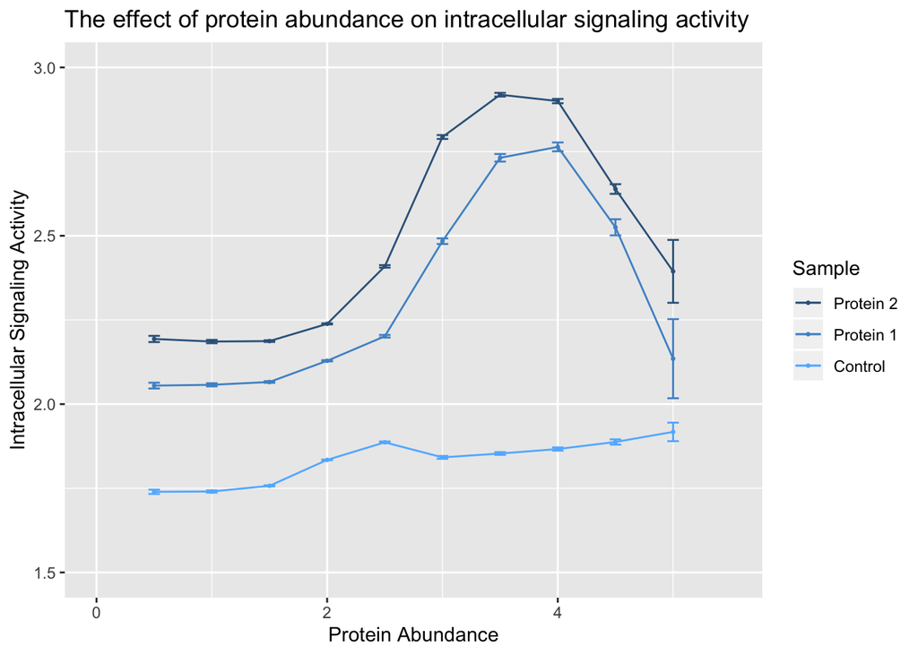

```r
# order samples as desired to appear in legend
longDat$Sample <- factor(longDat$Sample, levels = c("Protein 2", "Protein 1", "Control"))

# specify colors to be assigned to samples, ordered as specified above
sampleColors = c("steelblue4", "steelblue3", "steelblue1")

# plot the data
 ggplot(data = longDat, aes(x = x_bin, y = y_means, color = Sample)) +
   scale_color_manual(values = sampleColors) +
   geom_errorbar(aes(ymin = y_means - y_SEMs, ymax = y_means + y_SEMs), width = .1) +
   geom_line(aes(group = Sample)) + geom_point(size = 0.5) +
   ggtitle("The effect of protein abundance on intracellular signaling activity") +
   xlim(0, 5.5) +
   ylim(1.5, 3) +
   xlab("Protein Abundance") +
   ylab("Intracellular Signaling Activity")
```

Voilà! Now you can easily see the difference in these three samples using a single graph!

The control looks like it doesn’t “activate” intracellular signaling, whereas the experimental proteins are able to induce signaling within a certain range.